# Regression

## Name: Ryan Donaldson

## Date: 02/13/2023

### Summary

Linear regression is a statistical method used to find a relationship between predictor values, x, and target values y. The slope of the line and the intercept quantifies the amount that the target values change with respect to the predictor values. In other words, the line of best fit which will show an overall trend in the dataset and make accurate predictions. This can be interpreted as one strength of linear regression as the line of best fit can make the trend easy to interpret. It can also utilize multiple independent, or predictor, variables. However, linear regression does have its drawbacks in that any outliers can make it more difficult to understand the relationship along with variables that might not necessarily have a linear relationship.

Please click [here](https://www.kaggle.com/datasets/yasserh/uber-fares-dataset) to access the dataset used in this project. We will use linear regression to predict the fare price of an Uber ride based on the pickup and dropoff location.

#### Data Cleaning

Before exploring and visualizing data, let’s clean our dataset to make our overall linear regression model easier to work with as well as compiling informative graphs later on.

First, we will read the CSV and load the geosphere package so we can better work with latitude and longitude data that the columns will provide. We will also load the dplyr package to make column and row operations and mutations easier.

```r
Uber <- read.csv("uber.csv", na.strings="NA", header=TRUE)
if(!require("geosphere")) {
  install.packages("geosphere")
  library("geosphere")
}
if(!require("dplyr")) {
  install.packages("dplyr")
  library("dplyr", warn.conflicts=FALSE)
}
```

Let’s remove any rows which contain any latitude or longitude outliers.

```r
exclude_pickup_lon <- filter(Uber, pickup_longitude < -360
         | pickup_longitude > 360
         | pickup_longitude < -180
         | pickup_longitude > 180)
Uber <- anti_join(Uber, exclude_pickup_lon, by="key")

exclude_dropoff_lon <- filter(Uber, dropoff_longitude < -360
         | dropoff_longitude > 360
         | dropoff_longitude < -180
         | dropoff_longitude > 180)
Uber <- anti_join(Uber, exclude_dropoff_lon, by="key")

exclude_pickup_lat <- filter(Uber, pickup_latitude < -90
         | pickup_latitude > 90)
Uber <- anti_join(Uber, exclude_pickup_lat, by="key")

exclude_dropoff_lat <- filter(Uber, dropoff_latitude < -90
         | dropoff_latitude > 90)
Uber <- anti_join(Uber, exclude_dropoff_lat, by="key")
```

```r
print("Adding Distance column, please wait...")
```

```
[1] "Adding Distance column, please wait..."
```

```r
Uber <- Uber %>% rowwise() %>%
  mutate(Distance_In_Km=distHaversine(c(pickup_longitude, pickup_latitude), c(dropoff_longitude, dropoff_latitude)))
print("Uber dataframe has been mutated")
```

```
[1] "Uber dataframe has been mutated"
```

Now, we will divide the data into train and test sets using a 80/20 split.

```r
set.seed(1234)
i <- sample(1:nrow(Uber), nrow(Uber)*0.80,
replace=FALSE)
train <- Uber[i,]
test <- Uber[-i,]
```

#### Data Exploration

Next, we will run 5 R functions for data exploration of the data set using the training data. First, let’s run the str() function to get a look into the format of the data.

```r
str(train)
```

[output not shown]

[output cut: 59 more lines]

[output not shown]

Next, let’s gather an overall basic summary of each column of our training data.

```r
summary(train)
```

```
       X                key             fare_amount
 Min.   :       1   Length:159990      Min.   :-52.00
 1st Qu.:13886062   Class :character   1st Qu.:  6.00
 Median :27763618   Mode  :character   Median :  8.50
 Mean   :27749116                      Mean   : 11.37
 3rd Qu.:41600315                      3rd Qu.: 12.50
 Max.   :55423567                      Max.   :499.00

 pickup_datetime    pickup_longitude pickup_latitude  dropoff_longitude
 Length:159990      Min.   :-93.82   Min.   :-74.01   Min.   :-75.42
 Class :character   1st Qu.:-73.99   1st Qu.: 40.73   1st Qu.:-73.99
 Mode  :character   Median :-73.98   Median : 40.75   Median :-73.98
                    Mean   :-72.51   Mean   : 39.93   Mean   :-72.52
                    3rd Qu.:-73.97   3rd Qu.: 40.77   3rd Qu.:-73.96
                    Max.   : 40.81   Max.   : 48.02   Max.   : 40.83
                                                      NA's   :1
 dropoff_latitude passenger_count   Distance_In_Km
 Min.   :-74.02   Min.   :  0.000   Min.   :      0
 1st Qu.: 40.73   1st Qu.:  1.000   1st Qu.:   1216
 Median : 40.75   Median :  1.000   Median :   2127
 Mean   : 39.93   Mean   :  1.683   Mean   :  20083
 3rd Qu.: 40.77   3rd Qu.:  2.000   3rd Qu.:   3886
 Max.   : 45.03   Max.   :208.000   Max.   :8792737
 NA's   :1                          NA's   :1
```

Our summary above tells us that exploring missing data is really not necessary considering the `dropoff_longitude` and `dropoff_latitude` columns each only contain 1 NA. So, first let’s just look at the first few rows.

```r
head(train)
```

| X | key | fare_amount | pickup_datetime | pickup_longitude | pickup_latitude | dropoff_longitude | dropoff_latitude | passenger_count | Distance_In_Km |
| --- | --- | --- | --- | --- | --- | --- | --- | --- | --- |
| 20105724 | 2010-03-04 08:53:30.0000006 | 9.70 | 2010-03-04 08:53:30 UTC | -73.83019 | 40.75939 | -73.84577 | 40.78410 | 1 | 3047.640 |
| 18896163 | 2014-10-12 03:30:41.0000002 | 17.00 | 2014-10-12 03:30:41 UTC | -73.98607 | 40.74586 | -73.91459 | 40.76596 | 1 | 6428.656 |
| 40414748 | 2010-07-16 07:57:00.00000030 | 34.27 | 2010-07-16 07:57:00 UTC | -73.86414 | 40.77031 | -73.97346 | 40.75783 | 1 | 9320.839 |
| 11607434 | 2013-09-14 09:27:00.000000131 | 7.50 | 2013-09-14 09:27:00 UTC | -74.00118 | 40.72761 | -74.00721 | 40.71160 | 1 | 1853.417 |
| 34954013 | 2014-06-20 06:19:25.0000003 | 13.50 | 2014-06-20 06:19:25 UTC | -73.95669 | 40.78641 | -74.00287 | 40.75617 | 1 | 5146.622 |
| 29082183 | 2011-03-27 17:09:00.000000162 | 49.80 | 2011-03-27 17:09:00 UTC | -73.98962 | 40.75751 | -73.98962 | 40.75751 | 3 | 0.000 |

Now, let’s look at the last few rows of our training data.

```r
tail(train)
```

| X | key | fare_amount | pickup_datetime | pickup_longitude | pickup_latitude | dropoff_longitude | dropoff_latitude | passenger_count | Distance_In_Km |
| --- | --- | --- | --- | --- | --- | --- | --- | --- | --- |
| 55251256 | 2014-08-20 23:51:55.0000002 | 32.83 | 2014-08-20 23:51:55 UTC | -73.98886 | 40.73654 | -73.85475 | 40.72572 | 1 | 11376.2551 |
| 9135184 | 2012-07-09 08:28:31.0000001 | 4.10 | 2012-07-09 08:28:31 UTC | -74.00158 | 40.74558 | -73.99456 | 40.74587 | 1 | 592.1685 |
| 38983892 | 2010-06-25 12:27:48.0000004 | 4.50 | 2010-06-25 12:27:48 UTC | -73.99045 | 40.72889 | -73.98841 | 40.73757 | 1 | 981.6313 |
| 17122458 | 2011-04-26 01:03:03.0000001 | 8.50 | 2011-04-26 01:03:03 UTC | -74.00525 | 40.72032 | -73.99022 | 40.75697 | 1 | 4272.2295 |
| 28892833 | 2012-06-06 15:12:44.0000001 | 31.30 | 2012-06-06 15:12:44 UTC | -73.87460 | 40.77408 | -73.98547 | 40.75883 | 2 | 9500.7780 |
| 37672342 | 2012-05-09 21:34:00.000000118 | 9.30 | 2012-05-09 21:34:00 UTC | 0.00000 | 0.00000 | 0.00000 | 0.00000 | 5 | 0.0000 |

```r
names(train)
```

```
 [1] "X"                 "key"               "fare_amount"
 [4] "pickup_datetime"   "pickup_longitude"  "pickup_latitude"
 [7] "dropoff_longitude" "dropoff_latitude"  "passenger_count"
[10] "Distance_In_Km"
```

#### Data Visualization

Let’s create some informative graphs based on this training data, particuarly distributions of various columns since we’re working with such a large dataset. First, let’s get a sense of the distribution of ride distances.

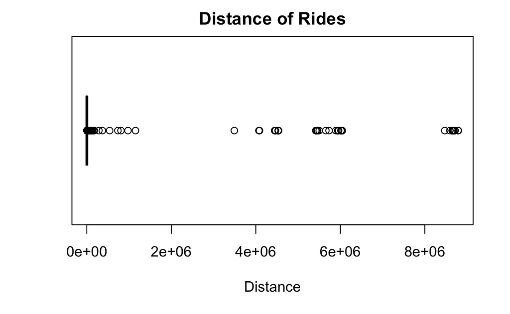

```r
boxplot(train$Distance_In_Km, col="slategray", horizontal=TRUE, xlab="Distance", main="Distance of Rides")
```

Next, let’s get a sense of the distribution of fare amounts.

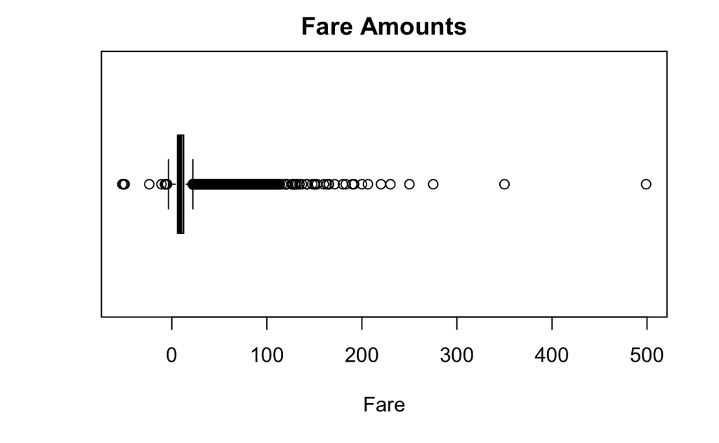

```r
boxplot(train$fare_amount, col="slategray", horizontal=TRUE, xlab="Fare", main="Fare Amounts")
```

Next, let’s get a sense of the distribution of passenger counts.

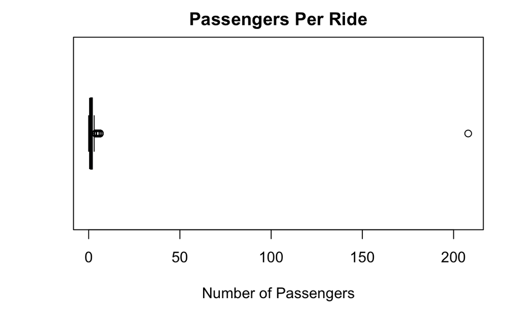

```r
boxplot(train$passenger_count, col="slategray", horizontal=TRUE, xlab="Number of Passengers", main="Passengers Per Ride")
```

After looking at the distribution among these columns, we’ve identified some outliers that would be best to remove.

Let’s further filter our Uber data set and then do a 80/20 split again.

```r
exclude_outliers <- filter(Uber, fare_amount < 0
         | fare_amount == 0
         | fare_amount > 60
         | passenger_count == 0
         | passenger_count > 6
         | Distance_In_Km == 0
         | Distance_In_Km > 80)
Uber <- anti_join(Uber, exclude_outliers, by="key")
```

Now, let’s divide the new filtered data into train and test sets using a 80/20 split.

```r
set.seed(1234)
i <- sample(1:nrow(Uber), nrow(Uber)*0.80,
replace=FALSE)
train <- Uber[i,]
test <- Uber[-i,]
```

Now that we’ve removed outliers, let’s see a histogram of the distance of rides.

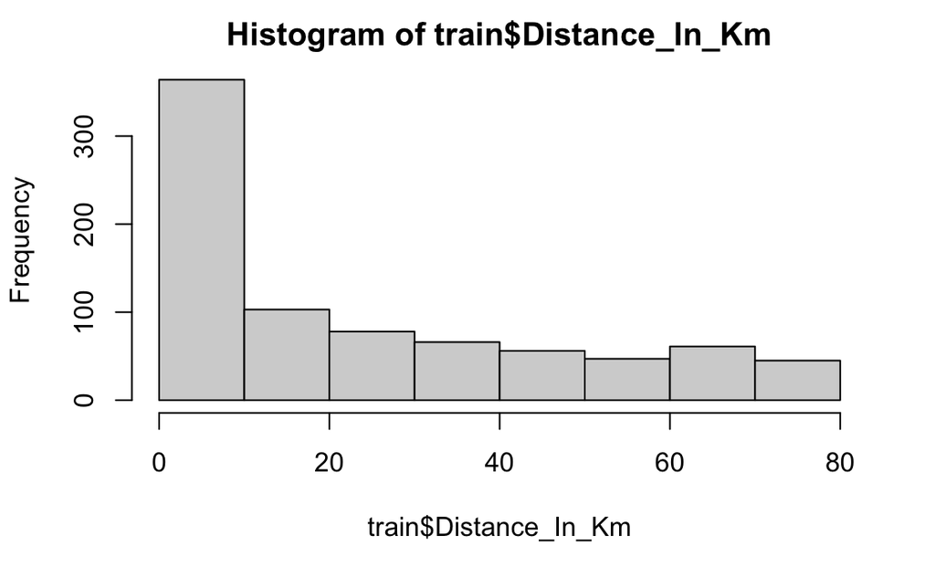

```r
hist(train$Distance_In_Km)
```

Now let’s see a histogram corresponding to fare amounts.

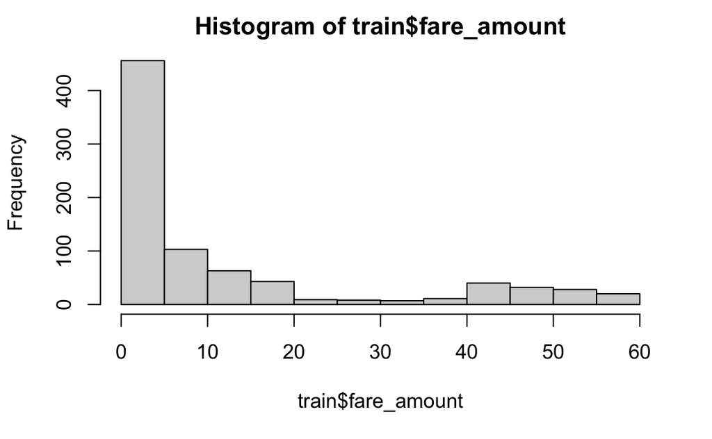

```r
hist(train$fare_amount)
```

### Linear Regression

Now, we will build a linear regression model and output the summary accordingly.

```r
lm1 <- lm(fare_amount~Distance_In_Km, data=train)
summary(lm1)
```

```
Call:
lm(formula = fare_amount ~ Distance_In_Km, data = train)

Residuals:
    Min      1Q  Median      3Q     Max
-15.832 -11.442  -6.373   2.771  49.072

Coefficients:
               Estimate Std. Error t value Pr(>|t|)
(Intercept)    16.17463    0.80996  19.970  < 2e-16 ***
Distance_In_Km -0.13068    0.02407  -5.428 7.52e-08 ***
---
Signif. codes:  0 ‘***’ 0.001 ‘**’ 0.01 ‘*’ 0.05 ‘.’ 0.1 ‘ ’ 1

Residual standard error: 16.52 on 818 degrees of freedom
Multiple R-squared:  0.03477,   Adjusted R-squared:  0.03359
F-statistic: 29.46 on 1 and 818 DF,  p-value: 7.516e-08
```

### Residual Plots

Next, we will predict target values, plot the residuals, and provide an explanation of what the plot tells us.

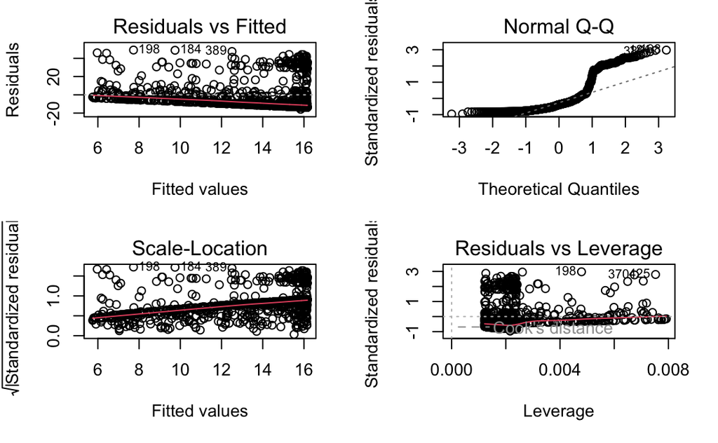

```r
par(mfrow=c(2,2))
plot(lm1)
```

Based on the residual plots, we can confirm our observations from the model summary. We know that the line of perfect fit represents where the residuals are equal to zero, and the red lines indicate the confidence of how far off the predicted values are from our actual values. Because there are many points above and below the red lines, this model does not fit the data well, as the variance for the residuals is not constant on these plots. For example, in the Normal Q-Q plot, there are many points above the dashed line, which shows that these residual values are not expected among a normal distribution. Because there are many smaller and larger than expected residuals, some outliers or other factors are still affecting the model’s accuracy.

### Multiple Linear Regression

So, let’s try using a linear regression model now with multiple predictors and output the summary and residual plots.

```r
lm2 <- lm(Distance_In_Km~fare_amount+passenger_count, data=train)
summary(lm2)
```

```
Call:
lm(formula = Distance_In_Km ~ fare_amount + passenger_count,
    data = train)

Residuals:
    Min      1Q  Median      3Q     Max
-26.436 -19.688  -8.374  16.587  64.939

Coefficients:
                Estimate Std. Error t value Pr(>|t|)
(Intercept)     27.35471    1.50543  18.171  < 2e-16 ***
fare_amount     -0.26626    0.04905  -5.428 7.51e-08 ***
passenger_count -0.16911    0.70596  -0.240    0.811
---
Signif. codes:  0 ‘***’ 0.001 ‘**’ 0.01 ‘*’ 0.05 ‘.’ 0.1 ‘ ’ 1

Residual standard error: 23.59 on 817 degrees of freedom
Multiple R-squared:  0.03483,   Adjusted R-squared:  0.03247
F-statistic: 14.74 on 2 and 817 DF,  p-value: 5.129e-07
```

Let’s output the residual plots.

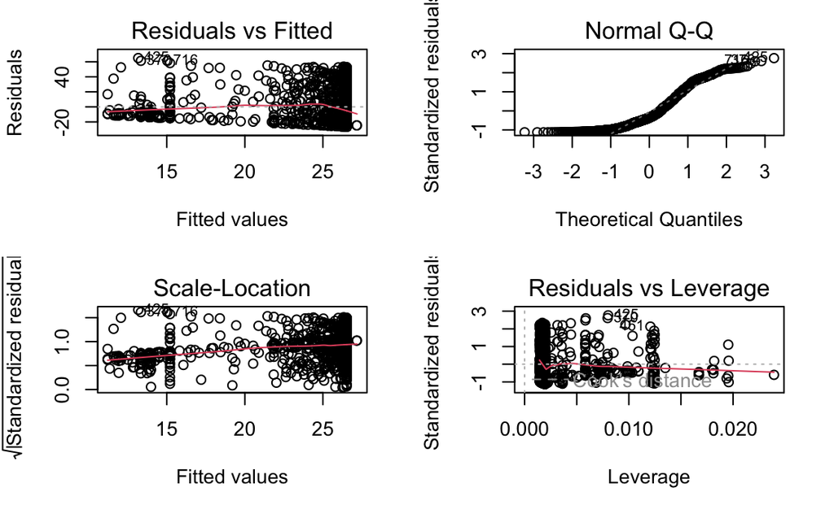

```r
par(mfrow=c(2,2))
plot(lm2)
```

### 3rd Linear Regression Model

Let’s build a third linear regression model to try and improve the results.

```r
lm3 <- lm(log(fare_amount)~Distance_In_Km+passenger_count, data=train)
summary(lm3)
```

```
Call:
lm(formula = log(fare_amount) ~ Distance_In_Km + passenger_count,
    data = train)

Residuals:
    Min      1Q  Median      3Q     Max
-6.6018 -0.9391 -0.4676  0.8216  2.3788

Coefficients:
                 Estimate Std. Error t value Pr(>|t|)
(Intercept)      2.015794   0.075522  26.691  < 2e-16 ***
Distance_In_Km  -0.005410   0.001643  -3.293  0.00104 **
passenger_count -0.005397   0.033742  -0.160  0.87297
---
Signif. codes:  0 ‘***’ 0.001 ‘**’ 0.01 ‘*’ 0.05 ‘.’ 0.1 ‘ ’ 1

Residual standard error: 1.128 on 817 degrees of freedom
Multiple R-squared:  0.01312,   Adjusted R-squared:  0.0107
F-statistic: 5.431 on 2 and 817 DF,  p-value: 0.004538
```

Let’s output the residual plots.

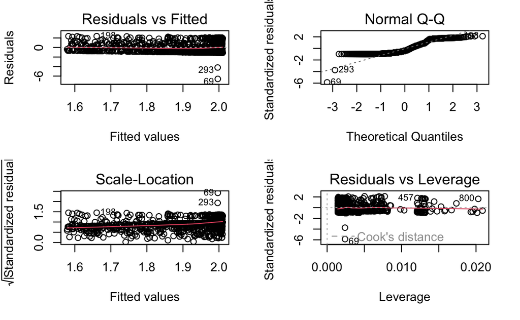

```r
par(mfrow=c(2,2))
plot(lm3)
```

### Prediction and Evaluation

Now, we will predict and evaluate on the test data using metrics correlation and mse for the first model.

```r
pred1 <- predict(lm1, newdata=test)
correlation1 <- cor(pred1, test$fare_amount)
print(paste("correlation: ", correlation1))
```

```
[1] "correlation:  0.170735464491682"
```

```r
mse1 <- mean((pred - test$fare_amount)^2)
print(paste("mse: ", mse1))
```

[output not shown]

Next, we will predict and evaluate on the test data using metrics correlation and mse for the second model.

```r
pred2 <- predict(lm2, newdata=test)
correlation2 <- cor(pred2, test$fare_amount)
print(paste("correlation: ", correlation2))
```

```
[1] "correlation:  -0.998854675216168"
```

```r
mse2 <- mean((pred - test$fare_amount)^2)
print(paste("mse: ", mse2))
```

[output not shown]

Finally, we will predict and evaluate on the test data using metrics correlation and mse for the third model.

```r
pred3 <- predict(lm3, newdata=test)
correlation3 <- cor(pred3, test$fare_amount)
print(paste("correlation: ", correlation3))
```

```
[1] "correlation:  0.173387981616032"
```

```r
mse3 <- mean((pred - test$fare_amount)^2)
print(paste("mse: ", mse3))
```

[output not shown]

#### Sources

- https://dplyr.tidyverse.org/index.html
- https://www.rdocumentation.org/packages/geosphere/versions/1.5-18
- https://r4ds.had.co.nz/transform.html#transform
- https://stackoverflow.com/questions/32363998/function-to-calculate-geospatial-distance-between-two-points-lat-long-using-r
- https://stackoverflow.com/questions/40554592/geosphere-disthaversine-dplyr-error-wrong-length-for-vector-should-be-2
- https://sebastiansauer.github.io/percentage_plot_ggplot2_V2/
- https://www.youtube.com/watch?v=MHbzCs05Luo
- https://github.com/kjmazidi/Machine_Learning_2nd_edition/tree/master/Part_2_Linear_Models